# Causal Inference Analysis of Asthma

WCM Modern Methods for Causal Inference Final Project

Yunqing Ma, Xiang Li, Yifan Wu

Jun 22, 2021

# Introduction

## Background

Treatment assignments usually varies from doctor to doctor, which should lead to different therapeutic effects. Whether there is significant difference between different treatment assignments for asthma becomes a great question.

## Dataset description

Two physician groups for asthma patients in California treated 276 patients in their own assignments, and collected several related variables. (JHSPH, 2018)

**The following are the outline of dataset:**

- `Physician Group`: treatment assignment (categorical, 1 or 2)
- `Age`: patients’ ages (continuous)
- `Sex`: patients’ genders (binary)
- `Education`: patients’ education levels (categorical)
- `Insurance Status`: patients’ insurance coverage levels (categorical)
- `Drug Coverage Status`: the current status of patients whether they take the medicine (binary, yes or no)
- `Severity`: the severity level of asthma (categorial)
- `Total Number of Comorbidity`: patients’ comorbidity (numerical)
- `Standard Physical Comorbidity Scale`: patients’ physical comorbidity in the standard scale (continuous)
- `Standard Mental Comorbidity Scale`: patients’ mental comorbidity in the standard scale (continuous)
- `Satisfaction Status of Patient`: the outcome of the treatment (binary, yes or no)

# Descriptive statistical analysis

## Pre-view of the basic information

```r
asthma <- read.table("asthma.txt", sep = "" , header = T , na.strings ="", stringsAsFactors= F)

dim(asthma)
```

```
## [1] 276  11
```

```r
library(tidyverse)
asthma$pg <- as.factor(asthma$pg)
asthma$i.sex = fct_collapse(factor(asthma$i.sex), Female = "1", Male = "0")
asthma$i.educ <- as.factor(asthma$i.educ)
asthma$i.insu <- as.factor(asthma$i.insu)
asthma$i.drug = fct_collapse(factor(asthma$i.drug), Yes = "1", No = "0")
asthma$i.seve <- as.factor(asthma$i.seve)
asthma$i.aqoc = fct_collapse(factor(asthma$i.aqoc), Yes = "1", No = "0")
asthma$pcs.sd <- round(asthma$pcs.sd, 3)
asthma$mcs.sd <- round(asthma$mcs.sd, 3)

sum(is.na(asthma))
```

```
## [1] 0
```

```r
colnames(asthma)=c("Physician Group","Age","Sex","Education","Insurance Status","Drug Coverage Status","Severity","Total Number of Comorbidity","Standard Physical Comorbidity Scale","Standard Mental Comorbidity Scale","Satisfaction Status of Patient")
```

The dimension of this dataset is 276 × 11. There are 276 obervations and 11 variables. No missing values are found. We first take a look at the first 6 observations to have a basic idea on the whole dataset (Table 1).

```r
library(kableExtra)
head(asthma)  %>%  kable(align = 'c', caption = "Table 1. Basic Information on Patients") %>% kable_classic_2()
```

Table 1. Basic Information on Patients

| Physician Group | Age | Sex | Education | Insurance Status | Drug Coverage Status | Severity | Total Number of Comorbidity | Standard Physical Comorbidity Scale | Standard Mental Comorbidity Scale | Satisfaction Status of Patient |
| --- | --- | --- | --- | --- | --- | --- | --- | --- | --- | --- |
| 1 | 36 | Male | 5 | 1 | Yes | 2 | 4 | 49.975 | 49.573 | Yes |
| 1 | 37 | Female | 6 | 2 | Yes | 3 | 3 | 40.940 | 56.114 | Yes |
| 1 | 43 | Female | 5 | 1 | Yes | 4 | 3 | 50.325 | 57.120 | Yes |
| 1 | 39 | Female | 6 | 1 | Yes | 4 | 1 | 49.344 | 49.652 | Yes |
| 1 | 46 | Female | 1 | 2 | Yes | 4 | 0 | 37.374 | 52.954 | No |
| 1 | 40 | Female | 3 | 1 | Yes | 3 | 2 | 40.561 | 50.667 | No |

```r
library(compareGroups)
library(dplyr)
library(kableExtra)

out <- compareGroups(`Satisfaction Status of Patient` ~ ., data = asthma, method = c(3,1,3,3,3,3,3,1,1,1), include.label = TRUE, simplify = T, byrow = TRUE)
res <- createTable(out, show.p.overall = F, extra.labels = c("","", ""))
#colnames(res$descr)[3] <- "p-value"
compareGroups::export2md(res, caption = "Table 2. Contingency Table for the Quality of Service provided by Two Physician Groups") %>% kable_styling(c("responsive", "condensed", "hover"), fixed_thead = T)
```

Table 2. Contingency Table for the Quality of Service provided by Two Physician Groups

|  | No | Yes |
| --- | --- | --- |
|  | N=90 | N=186 |
| Physician Group, N (%): |  |  |
| 1 | 23 (22.1%) | 81 (77.9%) |
| 2 | 67 (39.0%) | 105 (61.0%) |
| Age, Mean (SD) | 38.3 (8.83) | 40.8 (8.68) |
| Sex, N (%): |  |  |
| Male | 31 (37.3%) | 52 (62.7%) |
| Female | 59 (30.6%) | 134 (69.4%) |
| Education, N (%): |  |  |
| 1 | 1 (100%) | 0 (0.00%) |
| 2 | 0 (0.00%) | 4 (100%) |
| 3 | 5 (33.3%) | 10 (66.7%) |
| 4 | 29 (36.2%) | 51 (63.7%) |
| 5 | 28 (28.0%) | 72 (72.0%) |
| 6 | 27 (35.5%) | 49 (64.5%) |
| Insurance Status, N (%): |  |  |
| 1 | 59 (32.1%) | 125 (67.9%) |
| 2 | 24 (30.8%) | 54 (69.2%) |
| 3 | 0 (0.00%) | 1 (100%) |
| 5 | 7 (53.8%) | 6 (46.2%) |
| Drug Coverage Status, N (%): |  |  |
| No | 3 (60.0%) | 2 (40.0%) |
| Yes | 87 (32.1%) | 184 (67.9%) |
| Severity, N (%): |  |  |
| 1 | 9 (21.4%) | 33 (78.6%) |
| 2 | 18 (27.7%) | 47 (72.3%) |
| 3 | 46 (36.5%) | 80 (63.5%) |
| 4 | 17 (39.5%) | 26 (60.5%) |
| Total Number of Comorbidity, Mean (SD) | 1.79 (1.15) | 2.36 (1.55) |
| Standard Physical Comorbidity Scale, Mean (SD) | 46.9 (9.36) | 45.0 (10.6) |
| Standard Mental Comorbidity Scale, Mean (SD) | 50.0 (8.54) | 47.9 (10.3) |

## Data visualization

First, we have an overview on the distribution of numerical variables, including the `age`, `Standard Physical Comorbidity Scale`,`Standard Mental Comorbidity Scale`.

```r
patient1 <- asthma %>% filter(`Physician Group` == 1)
patient2 <- asthma %>% filter(`Physician Group` == 2)
```

- **Age**

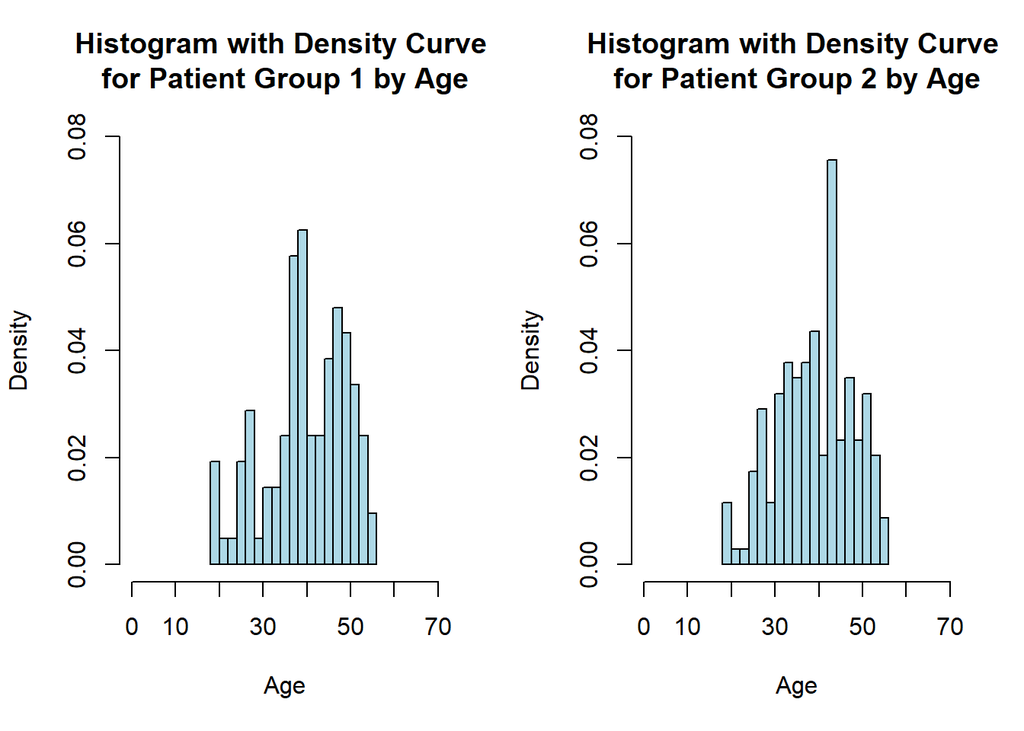

```r
attach(mtcars)
par(mfrow=c(1,2))

x<-patient1$Age
h<-hist(x, breaks=15, col="lightblue", border="black", prob = TRUE,xlab="Age",xlim=c(0,70),
        ylim=c(0,0.08),main="Histogram with Density Curve \nfor Patient Group 1 by Age")
#lines(density(x),col="blue", lwd=2)

x<-patient2$Age
h<-hist(x, breaks=15, col="lightblue", border="black", prob = TRUE,xlab="Age",xlim=c(0,70),
        ylim=c(0,0.08),main="Histogram with Density Curve \nfor Patient Group 2 by Age")
```

```r
#lines(density(x),col="blue", lwd=2)
```

- **Physical Comorbidity**

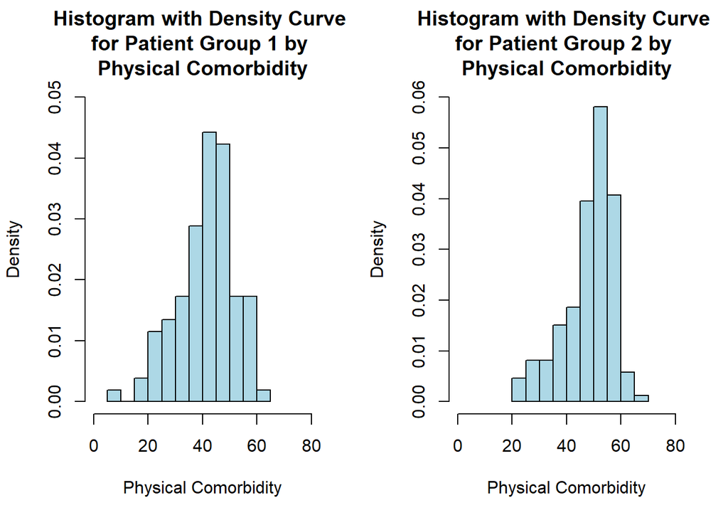

```r
par(mfrow=c(1,2))

x<-patient1$`Standard Physical Comorbidity Scale`
h<-hist(x, breaks=15, col="lightblue", border="black", prob = TRUE,xlab="Physical Comorbidity",xlim=c(0,80),
        ylim=c(0,0.05),main="Histogram with Density Curve \nfor Patient Group 1 by \nPhysical Comorbidity")
#lines(density(x),col="blue", lwd=2)

x<-patient2$`Standard Physical Comorbidity Scale`
h<-hist(x, breaks=15, col="lightblue", border="black", prob = TRUE,xlab="Physical Comorbidity",xlim=c(0,80),
        ylim=c(0,0.06),main="Histogram with Density Curve \nfor Patient Group 2 by \nPhysical Comorbidity")
```

```r
#lines(density(x),col="blue", lwd=2)
```

- **Mental Comorbidity**

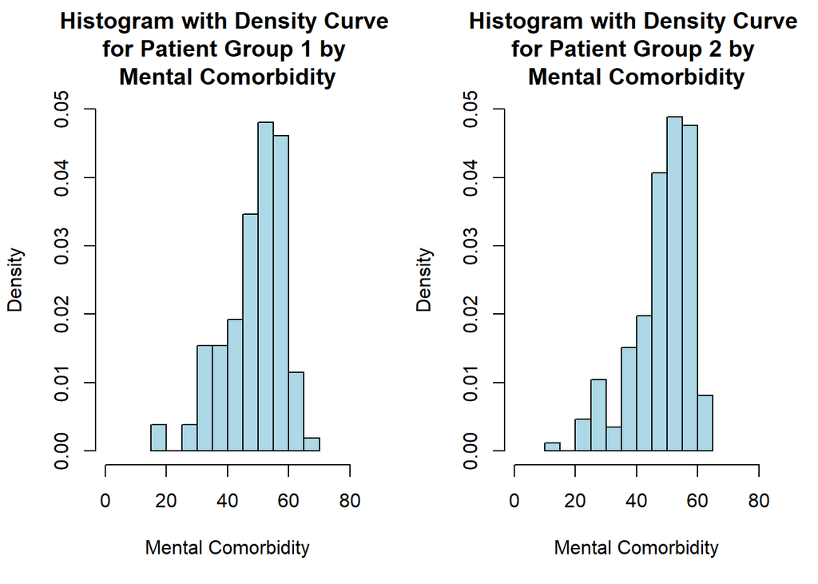

```r
par(mfrow=c(1,2))

x<-patient1$`Standard Mental Comorbidity Scale`
h<-hist(x, breaks=15, col="lightblue", border="black", prob = TRUE,xlab="Mental Comorbidity",xlim=c(0,80),
        ylim=c(0,0.05),main="Histogram with Density Curve \nfor Patient Group 1 by \nMental Comorbidity")
#lines(density(x),col="blue", lwd=2)

x<-patient2$`Standard Mental Comorbidity Scale`
h<-hist(x, breaks=15, col="lightblue", border="black", prob = TRUE,xlab="Mental Comorbidity",xlim=c(0,80),
        ylim=c(0,0.05),main="Histogram with Density Curve \nfor Patient Group 2 by \nMental Comorbidity")
```

```r
#lines(density(x),col="blue", lwd=2)
```

Typically, for patients’ physical comorbidity, boxplots below illustrate the difference in treatment outcomes between physician groups 1 and 2. In terms of mental comorbidity, there are the same results from two physician groups.

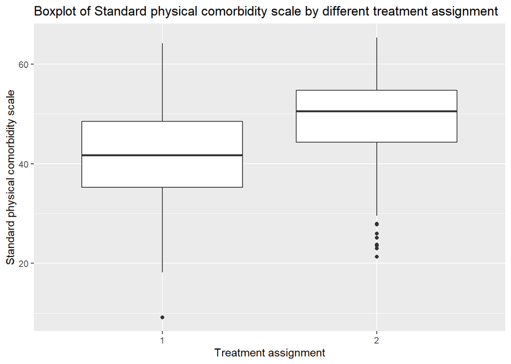

```r
ggplot(asthma, aes(x =`Physician Group` , y = `Standard Physical Comorbidity Scale`)) +
    geom_boxplot() +
    ggtitle('Boxplot of Standard physical comorbidity scale by different treatment assignment') +
    xlab('Treatment assignment') +
    ylab('Standard physical comorbidity scale')
```

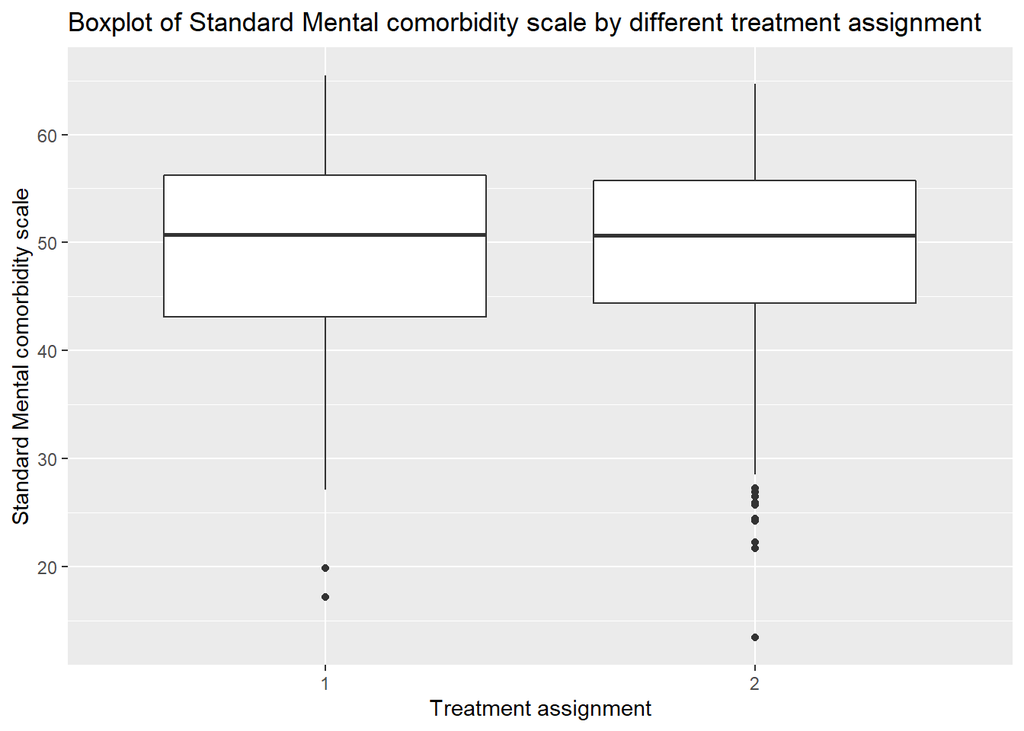

```r
ggplot(asthma, aes(x =`Physician Group` , y = `Standard Mental Comorbidity Scale`)) +
    geom_boxplot() +
    ggtitle('Boxplot of Standard Mental comorbidity scale by different treatment assignment') +
    xlab('Treatment assignment') +
    ylab('Standard Mental comorbidity scale')
```

# Reference

“Asthma Fact sheet No.307”. WHO. November 2013. Archived from the original on June 29, 2011. Retrieved 3 March 2016.

Asthma patients dataset. JHSPH. 2018. http://www.biostat.jhsph.edu/~cfrangak/biostat_causal/asthma.txt.

National Asthma Education and Prevention Program (2007). “Expert Panel Report 3: Guidelines for the Diagnosis and Management of Asthma”. National Heart Lung and Blood Institute. Archived from the original on 2013-10-19. Retrieved 2005-08-31.